# How well? - Human Activity Recognition

Zsolt Olah

March 18th, 2018

## Introduction

In the following analysis, we are going to build a prediction model using the [Human Activity Recognition database](http://groupware.les.inf.puc-rio.br/har). Our goal is to predict the manner of a given physical exercise based on accelerometer data.

## Preprocessing

For further considerations, we split the original training data into **train** and a **cross valiation** partition, which consist a 20% random sample (appr. 3900 obs.) of the initial training data.  
Looking at the data, one might notice the following crucial data characteristics: – there are many factor variables, some of them identifies the users of the accelerometers, the time of the measurement, and some numeric values also encoded into factor variables, presumably due to the high number of missing values (and hence low variability); – the share of missing data is relatively high across the variables, and in many cases, the occurence seems non-random.

Based on the above, we decided to incorporate those numeric variables with a low number of missing values. Moreover, factor variables describing the subjects and the measurement time considered irrelevant in evaluating the class of physical exercises (e.g. **X, user_name, time stamps, new_window**).

Since there is two type of variables respecting the proportion of the NA values (see Fig. below), only those with zero count of NAs will be considered.

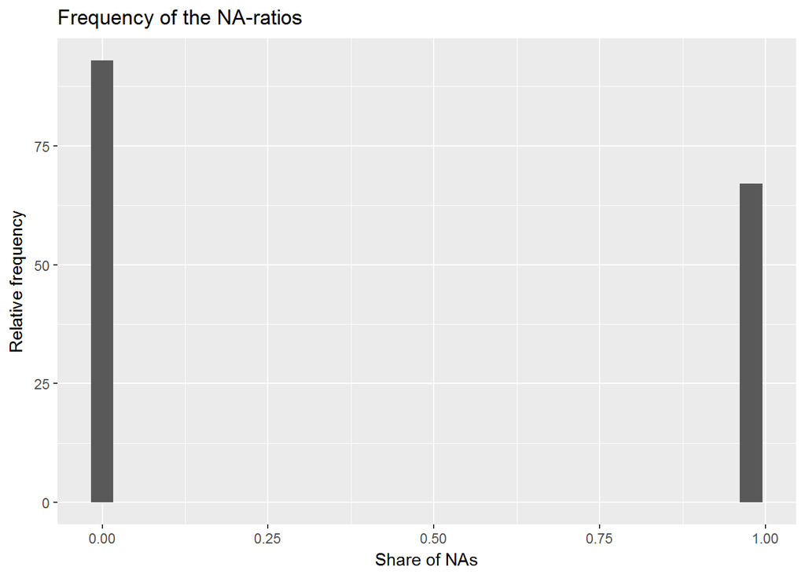

At the end of the variable *pre*-selection, we have 52 numeric features and variable **classe** as a categorical variable for the classification exercise.

## Building predictive models

For further exploration, we assess the correlation among the pre-selected features. As seen on the heatmap below, some variables have high pairwise correlation. In order to handle possible multicollinearity, we generate the principal components of the features.

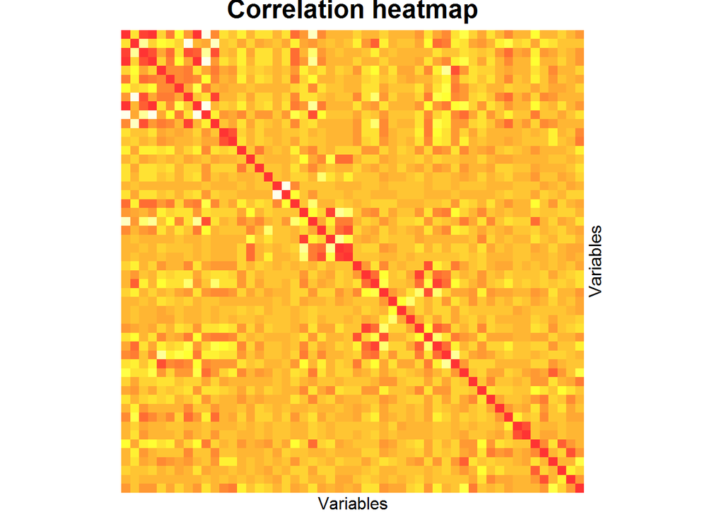

```
##               PC1       PC2       PC3       PC4       PC5       PC6
## Cum.var 0.1700244 0.3345609 0.4313913 0.5069875 0.5708745 0.6177311
##               PC7       PC8       PC9      PC10      PC11      PC12
## Cum.var 0.6607339 0.7013316 0.7359587 0.7694316 0.7976981 0.8244719
##              PC13      PC14      PC15      PC16     PC17      PC18
## Cum.var 0.8484907 0.8682906 0.8855371 0.9015608 0.916236 0.9301674
##              PC19     PC20      PC21      PC22      PC23      PC24
## Cum.var 0.9433173 0.953328 0.9628686 0.9715679 0.9796127 0.9867708
##              PC25 PC26
## Cum.var 0.9937266    1
```

```r
    ctrl <- trainControl(method="boot", number=10)
    ctrl2 <- trainControl(method="boot", number=50)

    op <- predict(pre_pca, train[,ids2])
    train_ <- data.frame(op[,1:24], classe=train$classe)
    model_pca <- train(classe ~., data=train_, method="multinom", trControl=ctrl)

    model_compl <- train(classe ~., data=train[,ids], method="multinom", trControl=ctrl)

    model_tree <- train(classe ~., data=train[,ids], method="rpart", trControl=ctrl2)
```

## Evaluating predictions - Predcition ensembling

Assessing the performance of each model, we could summarize the specifications as the followings. – Accuracy for the PCA model is: 51.5% – Accuracy for the complete multinomial model is: 66.5% – Accuracy for tree model is: 49.6%

Now, we estimate the accuracy of an ensembled predictor based on the predictions of the above models. To ensemble, random forest are built using the **ranger** package.

Accuracy of the random forest on the CV dataset: 71.4% (which is an in-sample accuracy along out-of-sample predictors).